# Reproducible Research: Peer Assessment 1

## Loading and preprocessing the data

1. Code for reading in and processing the dataset

```r
library(readr)
activity <- read_csv("activity.csv")
View(activity)
activity$date <- as.Date(activity$date, format = "%Y-%m-%d")
```

## What is mean total number of steps taken per day?

2. Histogram of the total number of steps taken per day

```r
activity_na <- activity[with(activity, {!(is.na(steps))}),]
steps_by_day_na <- aggregate(activity_na["steps"],
                             by = list(date = activity_na$date),
                             sum)
steps_by_day_na
```

```
##          date steps
## 1  2012-10-02   126
## 2  2012-10-03 11352
## 3  2012-10-04 12116
## 4  2012-10-05 13294
## 5  2012-10-06 15420
## 6  2012-10-07 11015
## 7  2012-10-09 12811
## 8  2012-10-10  9900
## 9  2012-10-11 10304
## 10 2012-10-12 17382
## 11 2012-10-13 12426
## 12 2012-10-14 15098
## 13 2012-10-15 10139
## 14 2012-10-16 15084
```

[output cut: 39 more lines]

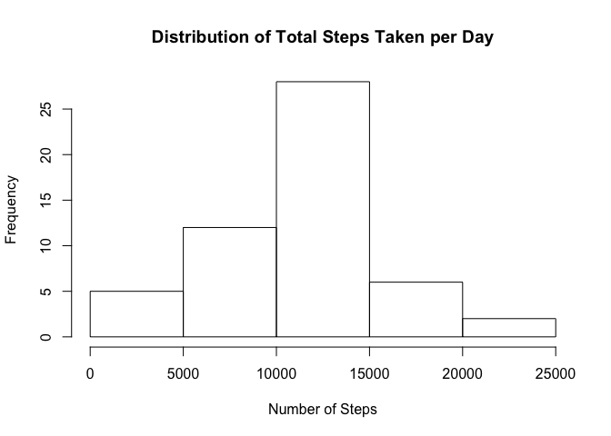

```r
hist(steps_by_day_na$steps,
     main = "Distribution of Total Steps Taken per Day",
     xlab = "Number of Steps")
```

3. Mean and median number of steps taken each day

```r
mean_steps_na <- mean(steps_by_day_na$steps)
mean_steps_na
```

```
## [1] 10766.19
```

```r
median_steps_na <- median(steps_by_day_na$steps)
median_steps_na
```

```
## [1] 10765
```

## What is the average daily activity pattern?

4. Time series plot of the averages number of steps taken per 5-minute interval

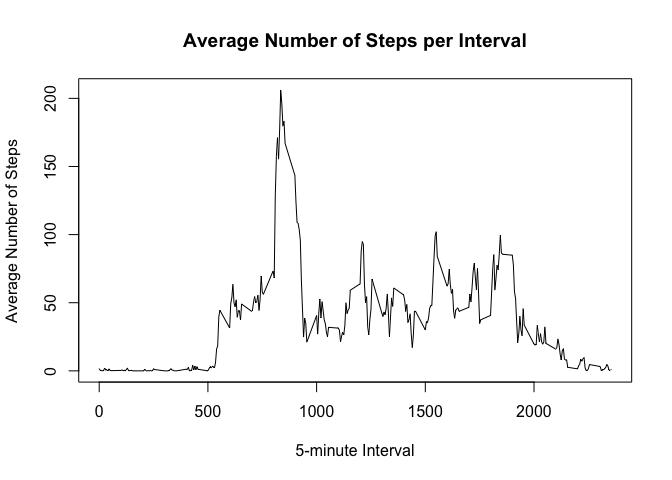

```r
steps_by_interval_na <- aggregate(activity_na["steps"],
                                  by = list(interval = activity_na$interval),
                                  mean)
plot(steps_by_interval_na$interval,
     steps_by_interval_na$steps,
     type = "l",
     main = "Average Number of Steps per Interval",
     xlab = "5-minute Interval",
     ylab = "Average Number of Steps")
```

5. The 5-minute interval that, on average, conains the maximum number of steps

```r
maximum_steps <- max(steps_by_interval_na$steps)
steps_by_interval_na[steps_by_interval_na$steps == maximum_steps, 1]
```

```
## [1] 835
```

## Imputing missing values

6. Code to describe and show a strategy for imputing missing data

```r
# Create dataset with only NA values intact
activity_complete <- activity
```

```r
# Determine number of missing values
missing_values_n <- nrow(activity_complete[is.na(activity_complete$steps), ])
```

The total number of missing values is 2304.

To account for missing data, missing values are replaced with the mean number of steps for that interval.

```r
# Create data set of mean number of steps for each day
activity_complete_imp <- transform(activity_complete,
                                   steps = ifelse(is.na(steps), ave(steps, interval, FUN = function(x) mean(x, na.rm = TRUE)), steps))

# Calculate total steps per day
steps_by_day_complete <- aggregate(activity_complete_imp["steps"],
                             by = list(date = activity_complete$date),
                             sum)
```

7. Histogram of the total number of steps taken each day after missing values are imputed

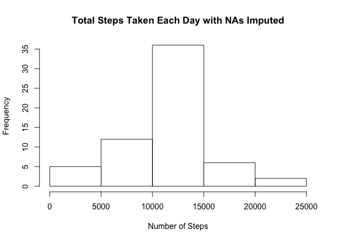

```r
hist(steps_by_day_complete$steps,
     main = "Total Steps Taken Each Day with NAs Imputed",
     xlab = "Number of Steps")
```

```r
steps_by_day_complete[, c("date", "steps")]
```

```
##          date    steps
## 1  2012-10-01 10766.19
## 2  2012-10-02   126.00
## 3  2012-10-03 11352.00
## 4  2012-10-04 12116.00
## 5  2012-10-05 13294.00
## 6  2012-10-06 15420.00
## 7  2012-10-07 11015.00
## 8  2012-10-08 10766.19
## 9  2012-10-09 12811.00
## 10 2012-10-10  9900.00
## 11 2012-10-11 10304.00
## 12 2012-10-12 17382.00
## 13 2012-10-13 12426.00
## 14 2012-10-14 15098.00
```

[output cut: 47 more lines]

```r
mean_steps_complete <- mean(steps_by_day_complete$steps)
median_steps_complete <- median(steps_by_day_complete$steps)
```

## Are there differences in activity patterns between weekdays and weekends?

8. Panel plot comparing the average number of steps taken per 5-minute interval across weekdays and weekends

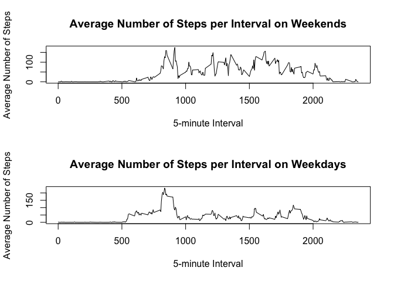

```r
activity_weekends <- activity_na[weekdays(as.Date(activity_na$date)) %in% c("Saturday", "Sunday"), ]
activity_weekdays <- activity_na[weekdays(as.Date(activity_na$date)) %in% c("Monday", "Tuesday", "Wednesday", "Thursday", "Friday"), ]

steps_by_interval_weekends <- aggregate(activity_weekends["steps"],
                                  by = list(interval = activity_weekends$interval),
                                  mean)
steps_by_interval_weekdays <- aggregate(activity_weekdays["steps"],
                                  by = list(interval = activity_weekdays$interval),
                                  mean)

par(mfrow = c(2, 1))
plot(steps_by_interval_weekends$interval,
     steps_by_interval_weekends$steps,
     type = "l",
     main = "Average Number of Steps per Interval on Weekends",
     xlab = "5-minute Interval",
     ylab = "Average Number of Steps")
plot(steps_by_interval_weekdays$interval,
     steps_by_interval_weekdays$steps,
     type = "l",
     main = "Average Number of Steps per Interval on Weekdays",
     xlab = "5-minute Interval",
     ylab = "Average Number of Steps")
```